# Marketing Analytics for a Food Delivery Platform

#### 30. Relationship between the total amount spent on gold, country, and the number of dependents (categorical split plot)

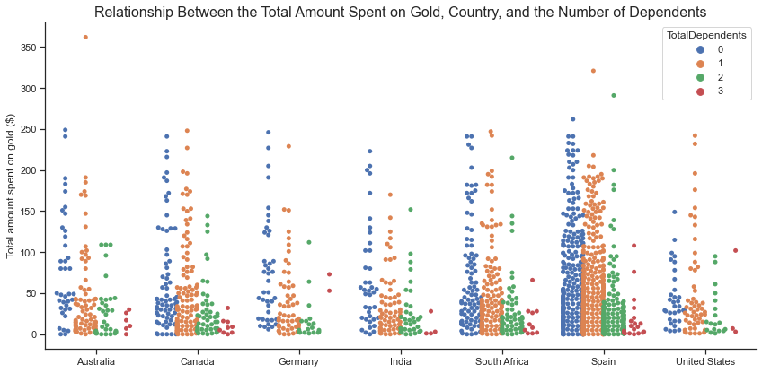

```python
sns.catplot(data=df,
            y="MntGoldProds",
            x ="Country",
            hue="TotalDependents",
            kind="swarm",
            aspect=2,
            height=6,
            dodge=True,
            legend_out=False);

plt.xlabel("")
plt.ylabel("Total amount spent on gold ($)")
plt.title("Relationship Between the Total Amount Spent on Gold, Country, and the Number of Dependents", size=16)
plt.tight_layout(pad=1.5);
```

#### 31. Relationship between total amount spent on gold, education, and the number of dependents (categorical point plot)

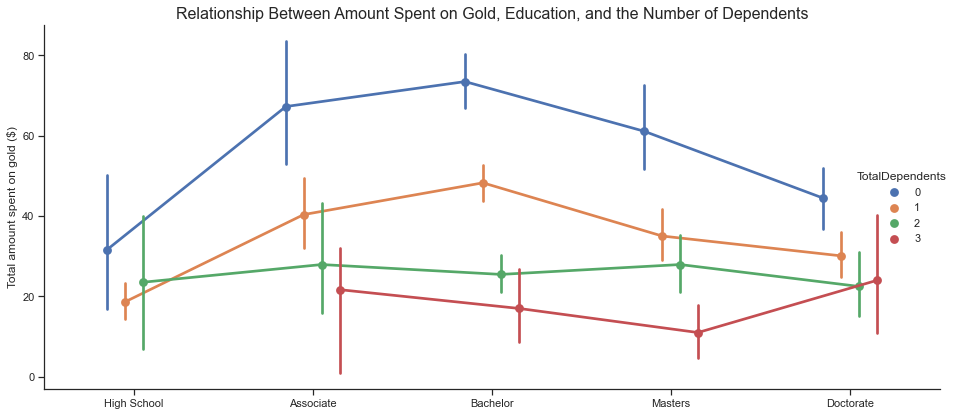

```python
sns.catplot(data=df,
            y="MntGoldProds",
            x = "Education",
            hue= "TotalDependents",
            kind= "point",
            aspect=2,
            height=6,
            dodge = 0.3);

plt.xlabel("")
plt.ylabel("Total amount spent on gold ($)")
plt.title("Relationship Between Amount Spent on Gold, Education, and the Number of Dependents", size=16)
plt.tight_layout(pad=1.5);
```

**Observation**: Across the board, regardless of educational background, those with 0 dependents spent more on gold than those who did have dependents. This trend is less pronounced with doctorates and those with high school education likely due to a lack of data. Around the bachelor level, there is lots of data so the trend is very strong.

#### 32. Relationship between income, total amount spent, and the number of dependents (categorical scatter plot)

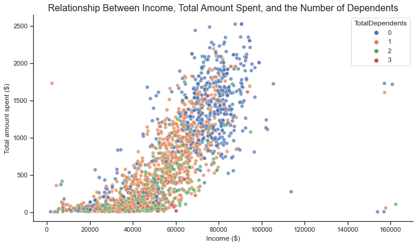

```python
sns.scatterplot(data=df,
                x="Income",
                y="TotalMnt",
                hue= "TotalDependents",
                palette='deep',
                s=40,
                alpha=0.7);

plt.xlabel("Income ($)")
plt.ylabel("Total amount spent ($)")
plt.title("Relationship Between Income, Total Amount Spent, and the Number of Dependents", size=16)
plt.tight_layout(pad=1.5);
```

**Observation**: This scatterplot simply reaffirms the trend that those with few or no dependents tend to make more money and coincidentally spend more. The up and to the right are the blue dots signifying 0 dependents.

#### 33. Relationship between education, marital status, total amount spent, and the number of purchases (facetted scatter plots)

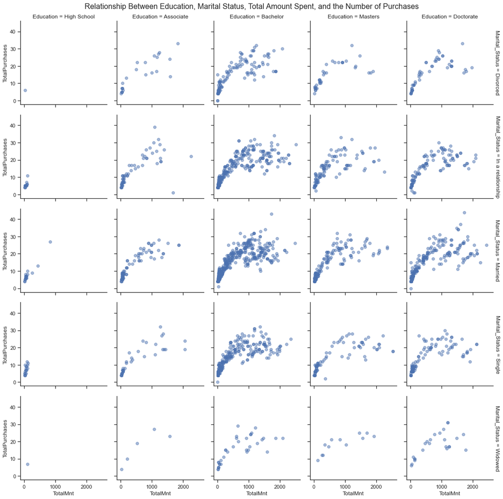

```python
g = sns.FacetGrid(data = df, col ='Education', row ="Marital_Status", margin_titles=True)
g.map(plt.scatter, 'TotalMnt', 'TotalPurchases', alpha=0.5);

g.fig.subplots_adjust(top=0.9)
g.fig.suptitle("Relationship Between Education, Marital Status, Total Amount Spent, and the Number of Purchases", size=16)
plt.tight_layout(pad=1.5)
```

**Observation**: This plot is a little difficult to extract a clear trend from. All that could be mentioned have been mentioned before clearer, simpler plots. This plot, I believe, is useful for identifying outliers. For example, two IDs that both identied as married and with a doctorate and bachelors degree had an unsually high purchase value and number of purchases. We can also see just how few widow IDs there are compared to other statuses. There is only one ID that identified as widowed with only a high school education.

#### 34. Summary statistics

```python
# Average customer demographic
demographics = pd.DataFrame(round(df[['Birth_Year', 'Age', 'Income', 'Kidhome', 'Teenhome', 'TotalDependents']].mean(),1), columns=["Average"])
demographics
```

|  | Average |
| --- | --- |
| Birth_Year | 1968.9 |
| Age | 46.1 |
| Income | 51945.1 |
| Kidhome | 0.4 |
| Teenhome | 0.5 |
| TotalDependents | 1.0 |

```python
# Average customer purchasing habits
purchasing_habits = pd.DataFrame(round(df[['Last_Purchase', 'MntWines', 'MntFruits', 'MntMeatProducts', 'MntFishProducts', 'MntSweetProducts','MntGoldProds',
       'TotalMnt','NumDealsPurchases', 'NumStorePurchases','NumWebPurchases', 'NumCatalogPurchases','TotalPurchases']].mean(),1), columns=["Average"])
purchasing_habits
```

|  | Average |
| --- | --- |
| Last_Purchase | 49.2 |
| MntWines | 303.5 |
| MntFruits | 26.3 |
| MntMeatProducts | 166.8 |
| MntFishProducts | 37.4 |
| MntSweetProducts | 27.1 |
| MntGoldProds | 43.8 |
| TotalMnt | 604.9 |
| NumDealsPurchases | 2.3 |
| NumStorePurchases | 5.8 |
| NumWebPurchases | 4.1 |
| NumCatalogPurchases | 2.7 |
| TotalPurchases | 14.8 |

**Note**: Code adapted from [here](https://www.kaggle.com/jennifercrockett/marketing-analytics-eda-task-final).

### Talk about some of the relationships you observed in this part of the investigation. Were there features that strengthened each other in terms of looking at your feature(s) of interest?

All opinions and insights expressed inline above.

### Were there any interesting or surprising interactions between features?

I was surprised to see that 0 dependents was be so correlated to high income, high spending, and high number of purchases. When you think about it, if you have a couple with no kids they have the most free money to spend. And perhaps they are career focus thus have a higher income on average.

## 7. Conclusions

Summary of insights and recommendations:

- The most successful campaign was the "Response" campaign, particularly in Spain and South Africa
  - Investigate what made this campaign so successful and adapt this model for future campaigns
- India had a relatively weak response to recent campaigns
  - Identify and rectify the issues responsible for the slump
- The most unsuccessful campaign was #2
  - Address reasons for the relative failure
    - However if the campaigns are labeled chronologically, then the issues were properly addressed consider that all campaigns have improved since #2
- Middle class professionals with 0 dependents and high incomes were the highest spenders while those with dependents did not spend as much
  - Focus on family friendly products or discounts and as targeting child/teen friendly items
- Wine and meat products were most successful
  - Sweets, fish, etc underperformed and should be promoted to fill gaps

```python
# Extras
pal = sns.color_palette("Greens_r",9)
```

```python
pal.as_hex()
```

```python
print(pal.as_hex())
```

```
['#006428', '#157f3b', '#2f974e', '#4bb062', '#75c477', '#98d594', '#b8e3b2', '#d3eecd', '#e9f7e5']
```

```python
pal = sns.color_palette("Blues_r",9)
```

```python
pal.as_hex()
```

```python
print(pal.as_hex())
```

```
['#084a91', '#1764ab', '#2e7ebc', '#4a98c9', '#6caed6', '#94c4df', '#b7d4ea', '#d0e1f2', '#e3eef9']
```

```python
# Save the dataframe
df.to_csv('marketing_cleaned.csv')
```